# Likelihood-based analysis of the packaged example data

`TruncComp2` provides two likelihood-based frequentist procedures for the two-group truncated-outcome problem:

- `method = "lrt"` for the parametric likelihood-ratio analysis
- `method = "splrt"` for the semi-parametric likelihood-ratio analysis

This vignette applies both methods to the packaged example data set used throughout the package documentation. The goal is to compare the fitted atom mechanism, the fitted mean contrast among the observed outcomes, and the combined-outcome contrast on the original outcome scale.

## Load the example data

```r
library(TruncComp2)

data("trunc_comp_example", package = "TruncComp2")
example_data <- transform(
  trunc_comp_example,
  A = as.integer(Y != 0)
)

head(example_data, 10)
```

```
#>    R        Y A
#> 1  0 0.000000 0
#> 2  0 5.444875 1
#> 3  0 0.000000 0
#> 4  0 0.000000 0
#> 5  0 0.000000 0
#> 6  0 0.000000 0
#> 7  0 5.206920 1
#> 8  0 3.830355 1
#> 9  0 5.555783 1
#> 10 0 0.000000 0
```

The packaged example uses `0` as the atom, so `A = 0` marks the undefined or unobserved outcome and `A = 1` marks rows where the continuous outcome is observed away from the atom.

As in the Bayesian vignette, it is useful to look at the example on the three most relevant scales before fitting either likelihood:

- the atom probability
- the mean among the non-atom outcomes
- the mean on the original combined-outcome scale

```r
arm_summary <- do.call(
  rbind,
  lapply(split(example_data, example_data$R), function(d) {
    data.frame(
      n = nrow(d),
      atom_probability = mean(d$A == 0L),
      observed_probability = mean(d$A == 1L),
      mean_non_atom = mean(d$Y[d$A == 1L]),
      mean_combined = mean(d$Y),
      row.names = NULL
    )
  })
)

arm_summary$arm <- c("control", "treatment")
arm_summary <- arm_summary[, c("arm", "n", "atom_probability",
                               "observed_probability", "mean_non_atom",
                               "mean_combined")]
arm_summary
```

```
#>         arm  n atom_probability observed_probability mean_non_atom
#> 0   control 25             0.40                 0.60      4.992855
#> 1 treatment 25             0.56                 0.44      6.849363
#>   mean_combined
#> 0      2.995713
#> 1      3.013720
```

This table makes the target quantities concrete. The two likelihood-based procedures below use the same atom and the same binary treatment indicator, but they differ in how strongly they model the non-atom outcome distribution.

## Fit the parametric and semi-parametric likelihoods

For the same formula interface, the package can fit either the parametric likelihood-ratio procedure or the semi-parametric likelihood-ratio procedure:

```r
fit_lrt <- trunc_comp(
  Y ~ R,
  atom = 0,
  data = example_data,
  method = "lrt"
)

fit_splrt <- trunc_comp(
  Y ~ R,
  atom = 0,
  data = example_data,
  method = "splrt"
)

fit_lrt
```

```
#> <trunc_comp_fit>
#> Call:
#> trunc_comp.formula(formula = Y ~ R, atom = 0, data = example_data,
#>     method = "lrt")
#> Method: Parametric likelihood-ratio test
#> Success: TRUE
#>    mu_delta alpha_delta       delta
#>  1.85650841  0.52380952  0.01800688
#>
#> Use summary() for confidence intervals and the joint test.
```

```r
fit_splrt
```

```
#> <trunc_comp_fit>
#> Call:
#> trunc_comp.formula(formula = Y ~ R, atom = 0, data = example_data,
#>     method = "splrt")
#> Method: Semi-parametric likelihood-ratio test
#> Success: TRUE
#>    mu_delta alpha_delta       delta
#>  1.85650841  0.52380952  0.01800688
#>
#> Use summary() for confidence intervals and the joint test.
```

The two printed objects report the same three fitted treatment-effect summaries:

- `mu_delta`: difference in means among the observed outcomes
- `alpha_delta`: odds ratio of being observed away from the atom
- `delta`: combined-outcome mean difference on the original scale

Each fit also stores the joint likelihood-ratio statistic and its p-value.

## Compare the fitted likelihood results

```r
fit_comparison <- data.frame(
  method = c("Parametric likelihood", "Semi-parametric likelihood"),
  mu_delta = c(fit_lrt$mu_delta, fit_splrt$mu_delta),
  alpha_delta = c(fit_lrt$alpha_delta, fit_splrt$alpha_delta),
  delta = c(fit_lrt$delta, fit_splrt$delta),
  statistic = c(fit_lrt$statistic, fit_splrt$statistic),
  p_value = c(fit_lrt$p.value, fit_splrt$p.value),
  row.names = NULL
)

fit_comparison
```

```
#>                       method mu_delta alpha_delta      delta statistic
#> 1      Parametric likelihood 1.856508   0.5238095 0.01800688  22.30228
#> 2 Semi-parametric likelihood 1.856508   0.5238095 0.01800688  31.09545
#>        p_value
#> 1 1.435887e-05
#> 2 1.768924e-07
```

The full printed summaries also expose the stored component confidence intervals and the joint likelihood-ratio result:

```r
summary(fit_lrt)
```

```
#> Call:
#> trunc_comp.formula(formula = Y ~ R, atom = 0, data = example_data,
#>     method = "lrt")
#>
#> Method: Parametric likelihood-ratio test
#> Confidence level = 95%
#>
#> Treatment contrasts
#>                                            Estimate  CI Lower CI Upper
#> Difference in means among the observed   1.85650841 1.1905752 2.522442
#> Odds ratio of being observed             0.52380952 0.1701898 1.612179
#> Combined-outcome mean difference (delta) 0.01800688        NA       NA
#>
#> Joint test statistic: 22.30228
#> p-value: 1.435887e-05
```

```r
summary(fit_splrt)
```

```
#> Call:
#> trunc_comp.formula(formula = Y ~ R, atom = 0, data = example_data,
#>     method = "splrt")
#>
#> Method: Semi-parametric likelihood-ratio test
#> Confidence level = 95%
#>
#> Treatment contrasts
#>                                            Estimate  CI Lower CI Upper
#> Difference in means among the observed   1.85650841 1.1638858 2.480101
#> Odds ratio of being observed             0.52380952 0.1660407 1.596820
#> Combined-outcome mean difference (delta) 0.01800688        NA       NA
#>
#> Joint test statistic: 31.09545
#> p-value: 1.768924e-07
```

Notice that the summary output reports the point estimate for the combined-outcome contrast `delta`, but leaves its confidence interval blank. That is intentional. Unlike `mu_delta` and `alpha_delta`, the package does not store one default interval for `delta` on the fitted object because there are multiple supported constructions for that interval, and they answer slightly different questions. Instead, `delta` intervals are computed on demand through `confint()` after you choose the interval type explicitly.

## Component confidence intervals

The component intervals are available directly through `confint()`:

```r
confint(fit_lrt)
```

```
#>                 2.5 %   97.5 %
#> mu_delta    1.1905752 2.522442
#> alpha_delta 0.1701898 1.612179
```

```r
confint(fit_splrt)
```

```
#>                 2.5 %   97.5 %
#> mu_delta    1.1638858 2.480101
#> alpha_delta 0.1660407 1.596820
```

These correspond to the two primary model components:

- the contrast in mean among the observed outcomes
- the odds ratio for being observed away from the atom

They are not exactly the same type of interval under the two methods.

- For `method = "lrt"`, both component intervals are Wald intervals from the fitted parametric submodels: a Normal-model interval for `mu_delta` and a logistic-model interval, exponentiated to the odds-ratio scale, for `alpha_delta`.
- For `method = "splrt"`, the interval for `mu_delta` is an empirical- likelihood interval based on the observed non-atom outcomes, while the interval for `alpha_delta` comes from profiling the logistic observation model and then exponentiating back to the odds-ratio scale.

For this example the fitted component intervals are again very similar across the two likelihood paths.

## Combined-outcome intervals for `delta`

Unlike the component intervals, intervals for the combined-outcome contrast `delta` are computed on demand. The package currently provides three choices:

- `method = "welch"` for a direct interval on the combined outcome
- `method = "profile"` for a profile-likelihood interval
- `method = "projected"` for a joint-surface projection interval

For the two likelihood-based `delta` constructions, `profile` and `projected`, there are actually two numerical ways to compute the interval:

- a default grid-based route, which evaluates the likelihood surface on a finite grid in `(mu_delta, log_or_delta)` space and then profiles or projects that surface
- an alternative optimizer-based route, which searches directly for the relevant `delta` endpoints without first building the full grid

In the public interface, this is controlled by the `algorithm` argument to `confint(..., parameter = "delta", method = "profile" | "projected")`. The default is `algorithm = "grid"`, which is usually the most transparent choice because it is tied directly to the same joint surface returned by `joint_contrast_surface()`. The optimizer-based route, `algorithm = "optimize"`, is available as a slower direct alternative. In this vignette, the `profile` and `projected` intervals below use that optimizer- based route.

```r
extract_delta_interval <- function(fit, method) {
  algorithm <- if(method %in% c("profile", "projected")) "optimize" else "grid"

  capture.output(
    interval <- confint(
      fit,
      parameter = "delta",
      method = method,
      algorithm = algorithm,
      plot = FALSE
    )
  )

  data.frame(
    lower = unname(interval[1, 1]),
    upper = unname(interval[1, 2]),
    row.names = NULL
  )
}

delta_interval_table <- do.call(
  rbind,
  lapply(
    list(
      list(label = "Parametric likelihood", fit = fit_lrt),
      list(label = "Semi-parametric likelihood", fit = fit_splrt)
    ),
    function(entry) {
      do.call(
        rbind,
        lapply(c("welch", "profile", "projected"), function(method_name) {
          interval <- extract_delta_interval(entry$fit, method_name)
          data.frame(
            method = entry$label,
            interval_type = if(method_name %in% c("profile", "projected")) {
              paste0(method_name, " (optimize)")
            } else {
              method_name
            },
            lower = interval$lower,
            upper = interval$upper,
            row.names = NULL
          )
        })
      )
    }
  )
)

delta_interval_table
```

```
#>                       method        interval_type     lower    upper
#> 1      Parametric likelihood                welch -1.739459 1.775472
#> 2      Parametric likelihood   profile (optimize) -1.556004 1.688868
#> 3      Parametric likelihood projected (optimize) -1.871030 2.054162
#> 4 Semi-parametric likelihood                welch -1.739459 1.775472
#> 5 Semi-parametric likelihood   profile (optimize) -1.256430 1.483426
#> 6 Semi-parametric likelihood projected (optimize) -1.820458 2.008450
```

On this data set the Welch interval is identical across the two fitted objects because it depends only on the observed combined outcome. The profile and projected intervals use the fitted likelihood surface and can differ slightly between the parametric and semi-parametric procedures.

## Joint confidence surfaces

For successful unadjusted fits, `TruncComp2` also exposes the joint likelihood-ratio surface in `(mu_delta, log_or_delta)`. This is the object that underlies the projected and profile-style `delta` intervals above.

Below is the joint confidence plot for the semi-parametric likelihood path on the same example data:

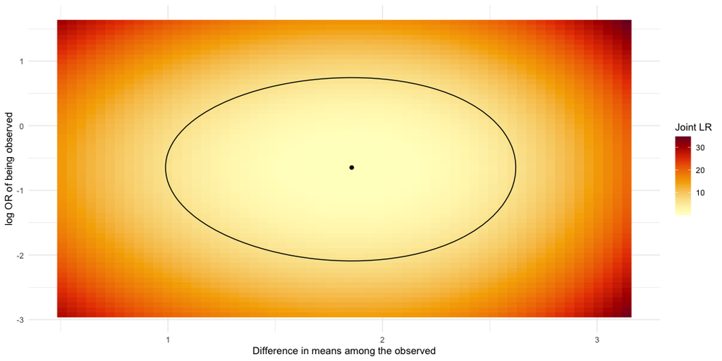

```r
joint_contrast_surface(fit_splrt, resolution = 60)
```